# *University Database Front-end*

# User Manual

## General

Welcome to the *University Database Front-end* User Manual. Here you will find how to operate the front-end from the perspective of many different types of users such as *Admins,* *Instructors,* and *Students.* This front-end is designed to safely and securely give you access to our University’s records with respect to your clearance and permission. Administrators will be given full access to all aspects of the database, while others can only view certain queries. You will also find troubleshooting for common misconceptions in the later parts of this manual.

## User Guide

As you access the front-end, the first thing you will be prompted with is the login screen. It appears as such:

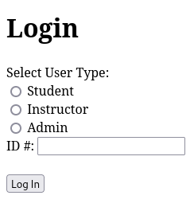

Login Screen

The `Select User Type:` selection prompts you to enter which type *you,* the user, are.

The `ID #:` field is where you must enter your *Student ID* for the purpose of verification.

*If you fail to do either of these, or the `ID #` is invalid, you will be prompted to retry.*

### Student

Upon a successful login as a *Student,* you should be prompted with the following interface:

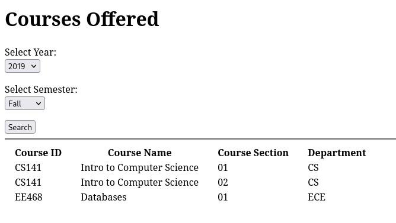

Courses Offered

Here, you will be able to view which courses are offered in a given semester.

The first selection is the year of the specified semester.

The next selection is what season the semester falls under.

Finally, click the `Search` button to submit the query.

*If you fail to do any of these, you will be prompted to retry.*

### Instructor

Upon a successful login as an *Instructor,* you should be prompted with the following interface:

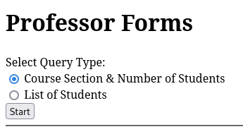

Professor Information

Here, you will be able to view one of two types of queries:

1. course section and number of students
2. list of students

Finally, click the `Start` button to continue.

*If you fail to do any of these, you will be prompted to retry.*

After clicking `Start` you will be prompted with the following interface:

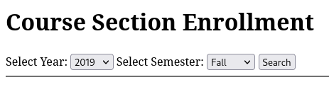

Here, you will select the year and the semester that you are searching for.

Click `Search` when you are satisfied with your selection.

The query results will appear below the horizontal line.

*If you fail to do any of these, you will be prompted to retry.*

## List of Students

After clicking `Start` you will be prompted with the following interface:

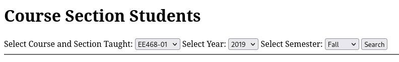

Here, you will select the Course/Section as well as year and semester.

Click `Search` when you are satisfied with your selection.

The query results will appear below the horizontal line.

*If you fail to do any of these, you will be prompted to retry.*

# Admin

Upon a successful login as an *Admin,* you should be prompted with the following interface:

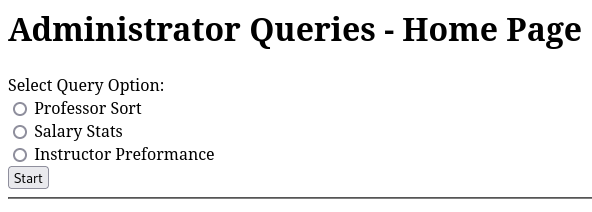

Administrator Queries

Here, you will be able to view one of three types of queries:

1. Professor Sort
2. Salary Stats
3. Instructor Performance

After selecting one of the aforementioned, click the `Start` button to continue.

If Salary Stats is selected, a table of instructor’s salaries will appear.

### Professor Sort

After clicking `Start` you will be prompted with the following interface:

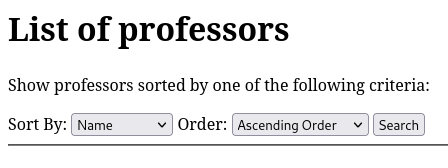

List of professors

Select the `Name` of the professor as well as the `order` to be sorted in.

Click `Search` when you are satisfied with your selection.

The query results will appear below the horizontal line.

*If you fail to do any of these, you will be prompted to retry.*

### Instructor Performance

After clicking `Start` you will be prompted with the following interface:

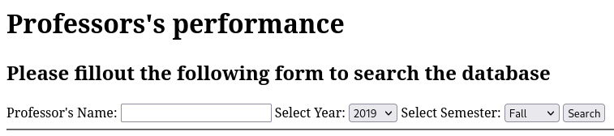

Professor’s Performance

Input the name of the professor as well as the `year` and `semester`.

Click `Search` when you are satisfied with your selection.

The query results will appear below the horizontal line.

*If you fail to do any of these, you will be prompted to retry.*

## Troubleshooting

### Invalid Login

It is a common issue that the user will accidentally select the wrong user type when logging in. Make sure that the `ID #` that you inputted corresponds to the type of user you have selected to be logged in as.